# Projekt

## Cel projektu

Celem niniejszego projektu jest zbudowanie modelu uczenia maszynowego, który będzie w stanie automatycznie klasyfikować zwierzęta w zoo na podstawie różnych cech. Klasyfikacja ta może być użyteczna w wielu kontekstach, takich jak zarządzanie zasobami zoo, edukacja odwiedzających, a także w badaniach naukowych dotyczących zachowań i ekologii zwierząt.

## Znaczenie klasyfikacji zwierząt

Klasyfikacja zwierząt jest kluczowym zadaniem w biologii, ekologii i zarządzaniu dziką przyrodą. Pozwala na lepsze zrozumienie różnorodności biologicznej, zależności między gatunkami oraz ich roli w ekosystemach. W kontekście zoo, skuteczna klasyfikacja umożliwia lepsze zarządzanie zdrowiem i dobrostanem zwierząt, optymalizację przestrzeni oraz planowanie interakcji z odwiedzającymi.

Wgrywamy potrzebne biblioteki i nasze dane.

```python
pip install -U scikit-learn
```

```
     ━━━━━━━━━━━━━━━━━━━━━━━━━━━━━━━━━━━━━━━━ 13.3/13.3 MB 21.7 MB/s eta 0:00:00
  Attempting uninstall: scikit-learn
    Found existing installation: scikit-learn 1.2.2
    Uninstalling scikit-learn-1.2.2:
      Successfully uninstalled scikit-learn-1.2.2
```

```python
import pandas as pd
import numpy as np
import seaborn as sns
import pandas as pd
import io
import matplotlib.pyplot as plt
import plotly.express as px

from sklearn.metrics.pairwise import cosine_similarity
from sklearn.model_selection import train_test_split
from sklearn.linear_model import LinearRegression, LogisticRegression
from sklearn.metrics import mean_squared_error, r2_score, accuracy_score, precision_score, recall_score, f1_score, confusion_matrix, classification_report
from sklearn import datasets
from statsmodels.stats.outliers_influence import variance_inflation_factor
from sklearn.experimental import enable_iterative_imputer
from sklearn.impute import IterativeImputer
from sklearn.preprocessing import LabelEncoder, StandardScaler
from sklearn.neighbors import KNeighborsClassifier
from sklearn.svm import SVC
from sklearn.tree import DecisionTreeClassifier
from sklearn.ensemble import RandomForestClassifier, GradientBoostingClassifier
from sklearn.cluster import AgglomerativeClustering, KMeans
from sklearn.decomposition import PCA

import warnings
warnings.filterwarnings('ignore')

seed = 25
seed_v2 = 52
```

```python
from google.colab import files

uploaded = files.upload()
```

Upload widget is only available when the cell has been executed in the current browser session. Please rerun this cell to enable.

```
Saving zoo.csv to zoo.csv
```

```python
from google.colab import files

uploaded = files.upload()
```

Upload widget is only available when the cell has been executed in the current browser session. Please rerun this cell to enable.

```
Saving class.csv to class.csv
```

## Dane

```python
zoo = pd.read_csv('zoo.csv')
zoo.head()
```

|  | animal_name | hair | feathers | eggs | milk | airborne | aquatic | predator | toothed | backbone | breathes | venomous | fins | legs | tail | domestic | catsize | class_type |
| --- | --- | --- | --- | --- | --- | --- | --- | --- | --- | --- | --- | --- | --- | --- | --- | --- | --- | --- |
| 0 | aardvark | 1 | 0 | 0 | 1 | 0 | 0 | 1 | 1 | 1 | 1 | 0 | 0 | 4 | 0 | 0 | 1 | 1 |
| 1 | antelope | 1 | 0 | 0 | 1 | 0 | 0 | 0 | 1 | 1 | 1 | 0 | 0 | 4 | 1 | 0 | 1 | 1 |
| 2 | bass | 0 | 0 | 1 | 0 | 0 | 1 | 1 | 1 | 1 | 0 | 0 | 1 | 0 | 1 | 0 | 0 | 4 |
| 3 | bear | 1 | 0 | 0 | 1 | 0 | 0 | 1 | 1 | 1 | 1 | 0 | 0 | 4 | 0 | 0 | 1 | 1 |
| 4 | boar | 1 | 0 | 0 | 1 | 0 | 0 | 1 | 1 | 1 | 1 | 0 | 0 | 4 | 1 | 0 | 1 | 1 |

Do stworzenia modelu klasyfikacji wykorzystamy zbiór danych o zwierzętach, zawierający informacje o różnych cechach fizycznych i behawioralnych zwierząt oraz ich klasyfikację. Zbiór danych składa się z 101 wierszy i 18 kolumn. Oto szczegółowy opis każdej kolumny:

- `animal_name`: Nazwa zwierzęcia (np. aardvark, antelope, bass).
- `hair`: Czy zwierzę ma włosy (1 = tak, 0 = nie).
- `feathers`: Czy zwierzę ma pióra (1 = tak, 0 = nie).
- `eggs`: Czy zwierzę składa jaja (1 = tak, 0 = nie).
- `milk`: Czy zwierzę produkuje mleko (1 = tak, 0 = nie).
- `airborne`: Czy zwierzę potrafi latać (1 = tak, 0 = nie).
- `aquatic`: Czy zwierzę jest wodne (1 = tak, 0 = nie).
- `predator`: Czy zwierzę jest drapieżnikiem (1 = tak, 0 = nie).
- `toothed`: Czy zwierzę ma zęby (1 = tak, 0 = nie).
- `backbone`: Czy zwierzę ma kręgosłup (1 = tak, 0 = nie).
- `breathes`: Czy zwierzę oddycha powietrzem (1 = tak, 0 = nie).
- `venomous`: Czy zwierzę jest jadowite (1 = tak, 0 = nie).
- `fins`: Czy zwierzę ma płetwy (1 = tak, 0 = nie).
- `legs`: Liczba nóg (np. 0, 2, 4, 6, 8).
- `tail`: Czy zwierzę ma ogon (1 = tak, 0 = nie).
- `domestic`: Czy zwierzę jest udomowione (1 = tak, 0 = nie).
- `catsize`: Czy zwierzę jest wielkości kota lub większe (1 = tak, 0 = nie).
- `class_type`: Typ klasyfikacji zwierzęcia (liczba całkowita, która może reprezentować różne grupy, np. ssaki, ptaki, gady itd.).

Każdy wiersz odpowiada jednemu zwierzęciu i zawiera wartości binarne (0 lub 1) lub liczbowe (np. liczba nóg) opisujące cechy tego zwierzęcia. Kolumna `class_type` reprezentuje etykietę klasy dla każdego zwierzęcia, co jest celem predykcji w zadaniu klasyfikacji.

### Przykład:

`antelope`: Ma włosy, nie ma piór, nie składa jaj, produkuje mleko, nie potrafi latać, nie jest wodne, nie jest drapieżnikiem, ma zęby, ma kręgosłup, oddycha powietrzem, nie jest jadowite, nie ma płetw, ma 4 nogi, ma ogon, nie jest udomowione, klasa 1.

## Wnioski

Zbiór danych jest dobrze zorganizowany i zawiera zarówno cechy binarne, jak i liczbowe, co pozwala na zastosowanie różnych technik uczenia maszynowego do klasyfikacji zwierząt. Dane te mogą być wykorzystane do trenowania modeli klasyfikacyjnych, które będą mogły automatycznie przypisywać nowe zwierzęta do odpowiednich klas na podstawie ich cech.

```python
class1 = pd.read_csv("class.csv")
class1
```

|  | Class_Number | Number_Of_Animal_Species_In_Class | Class_Type | Animal_Names |
| --- | --- | --- | --- | --- |
| 0 | 1 | 41 | Mammal | aardvark, antelope, bear, boar, buffalo, calf,... |
| 1 | 2 | 20 | Bird | chicken, crow, dove, duck, flamingo, gull, haw... |
| 2 | 3 | 5 | Reptile | pitviper, seasnake, slowworm, tortoise, tuatara |
| 3 | 4 | 13 | Fish | bass, carp, catfish, chub, dogfish, haddock, h... |
| 4 | 5 | 4 | Amphibian | frog, frog, newt, toad |
| 5 | 6 | 8 | Bug | flea, gnat, honeybee, housefly, ladybird, moth... |
| 6 | 7 | 10 | Invertebrate | clam, crab, crayfish, lobster, octopus, scorpi... |

Druga tabela przedstawia informacje o klasyfikacji zwierząt na różne klasy. Zawiera ona cztery kolumny:

- `Class_Number`: Numer klasy, który jest używany jako etykieta klasy w danych.
- `Number_Of_Animal_Species_In_Class`: Liczba gatunków zwierząt należących do danej klasy.
- `Class_Type`: Typ klasy, czyli kategoria, do której należą zwierzęta (np. Mammal, Bird, Reptile).
- `Animal_Names`: Lista nazw zwierząt należących do danej klasy.

Tabela ta służy jako słownik do interpretacji kolumny `class_type` z poprzedniego zbioru danych o zwierzętach. Dzięki niej można zrozumieć, jakie typy zwierząt są przypisane do poszczególnych numerów klas. Na przykład, klasa 1 odpowiada ssakom, klasa 2 ptakom, a klasa 3 gadom. Taka struktura danych ułatwia analizę i zrozumienie, jakie cechy charakteryzują poszczególne grupy zwierząt oraz jak są one klasyfikowane w zbiorze danych.

## Podstawowe informacje o naszych danych

```python
zoo.info()
```

```
<class 'pandas.core.frame.DataFrame'>
RangeIndex: 101 entries, 0 to 100
Data columns (total 18 columns):
 #   Column       Non-Null Count  Dtype
---  ------       --------------  -----
 0   animal_name  101 non-null    object
 1   hair         101 non-null    int64
 2   feathers     101 non-null    int64
 3   eggs         101 non-null    int64
 4   milk         101 non-null    int64
 5   airborne     101 non-null    int64
 6   aquatic      101 non-null    int64
 7   predator     101 non-null    int64
 8   toothed      101 non-null    int64
 9   backbone     101 non-null    int64
 10  breathes     101 non-null    int64
 11  venomous     101 non-null    int64
 12  fins         101 non-null    int64
 13  legs         101 non-null    int64
 14  tail         101 non-null    int64
 15  domestic     101 non-null    int64
 16  catsize      101 non-null    int64
 17  class_type   101 non-null    int64
dtypes: int64(17), object(1)
memory usage: 14.3+ KB
```

Zbiór danych zoo składa się ze 101 wierszy i 18 kolumn, w których każda kolumna nie zawiera brakujących wartości. Wszystkie kolumny, poza `animal_name`, mają typ danych int64 (liczby całkowite), a `animal_name` jest typu object (ciągi znaków).

```python
zoo.describe()
```

|  | hair | feathers | eggs | milk | airborne | aquatic | predator | toothed | backbone | breathes | venomous | fins | legs | tail | domestic | catsize | class_type |
| --- | --- | --- | --- | --- | --- | --- | --- | --- | --- | --- | --- | --- | --- | --- | --- | --- | --- |
| count | 101.000000 | 101.000000 | 101.000000 | 101.000000 | 101.000000 | 101.000000 | 101.000000 | 101.000000 | 101.000000 | 101.000000 | 101.000000 | 101.000000 | 101.000000 | 101.000000 | 101.000000 | 101.000000 | 101.000000 |
| mean | 0.425743 | 0.198020 | 0.584158 | 0.405941 | 0.237624 | 0.356436 | 0.554455 | 0.603960 | 0.821782 | 0.792079 | 0.079208 | 0.168317 | 2.841584 | 0.742574 | 0.128713 | 0.435644 | 2.831683 |
| std | 0.496921 | 0.400495 | 0.495325 | 0.493522 | 0.427750 | 0.481335 | 0.499505 | 0.491512 | 0.384605 | 0.407844 | 0.271410 | 0.376013 | 2.033385 | 0.439397 | 0.336552 | 0.498314 | 2.102709 |
| min | 0.000000 | 0.000000 | 0.000000 | 0.000000 | 0.000000 | 0.000000 | 0.000000 | 0.000000 | 0.000000 | 0.000000 | 0.000000 | 0.000000 | 0.000000 | 0.000000 | 0.000000 | 0.000000 | 1.000000 |
| 25% | 0.000000 | 0.000000 | 0.000000 | 0.000000 | 0.000000 | 0.000000 | 0.000000 | 0.000000 | 1.000000 | 1.000000 | 0.000000 | 0.000000 | 2.000000 | 0.000000 | 0.000000 | 0.000000 | 1.000000 |
| 50% | 0.000000 | 0.000000 | 1.000000 | 0.000000 | 0.000000 | 0.000000 | 1.000000 | 1.000000 | 1.000000 | 1.000000 | 0.000000 | 0.000000 | 4.000000 | 1.000000 | 0.000000 | 0.000000 | 2.000000 |
| 75% | 1.000000 | 0.000000 | 1.000000 | 1.000000 | 0.000000 | 1.000000 | 1.000000 | 1.000000 | 1.000000 | 1.000000 | 0.000000 | 0.000000 | 4.000000 | 1.000000 | 0.000000 | 1.000000 | 4.000000 |
| max | 1.000000 | 1.000000 | 1.000000 | 1.000000 | 1.000000 | 1.000000 | 1.000000 | 1.000000 | 1.000000 | 1.000000 | 1.000000 | 1.000000 | 8.000000 | 1.000000 | 1.000000 | 1.000000 | 7.000000 |

Dane przedstawiają opis podstawowych informacji statystycznych, takich jak średnia, odchylenie standardowe, wartość najmniejsza i największa, a także kwartyle.

Wyświetlamy jeszcze raz kolumny z naszegoo zbioru danych.

```python
cols = zoo.columns
cols
```

```
Index(['animal_name', 'hair', 'feathers', 'eggs', 'milk', 'airborne',
       'aquatic', 'predator', 'toothed', 'backbone', 'breathes', 'venomous',
       'fins', 'legs', 'tail', 'domestic', 'catsize', 'class_type'],
      dtype='object')
```

## Wizualizacja danych

Wyświetlamy liczebność każdego gatunku w naszym zbiorze danych.

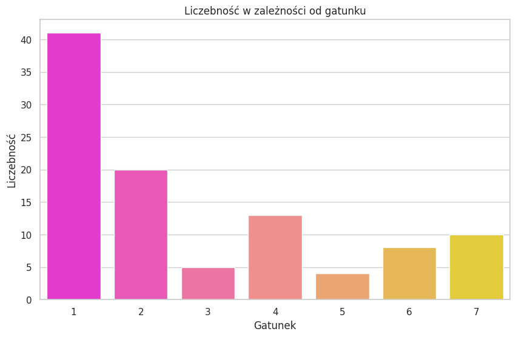

```
class_type
1    41
2    20
4    13
7    10
6     8
3     5
5     4
Name: count, dtype: int64
```

```python
sns.set(style="whitegrid")

plt.figure(figsize=(10, 6))
palette = sns.color_palette("spring", len(zoo['class_type'].unique()))
sns.countplot(x=zoo['class_type'], palette=palette)
plt.xlabel('Gatunek')
plt.ylabel('Liczebność')
plt.title('Liczebność w zależności od gatunku')
plt.show()

print(pd.Series.value_counts(zoo['class_type']))
```

```python
import plotly.express as px

NumberofPlayers = zoo.groupby(pd.Grouper(key='class_type')).size().reset_index(name='count')
fig = px.treemap(NumberofPlayers, path=['class_type'], values='count')
fig.update_layout(title_text='Podział na typy klas zwierząt',
                  title_x=0.5, title_font=dict(size=25))
fig.update_traces(textinfo="label+value")

fig.show()
```

[interactive chart not shown]

```python
labels = [" 1"," 2"," 3"," 4"," 5"," 6"," 7"]
values = zoo['class_type'].value_counts().tolist()

px.pie(zoo, values=values, names=labels, title="Wykres kołowy rozkładu klas zwierząt")
```

[interactive chart not shown]

## Inne ciekawe wykresy

#### Liczebność nóg

```python
zoo["legs"].unique()
```

```
array([4, 0, 2, 6, 8, 5])
```

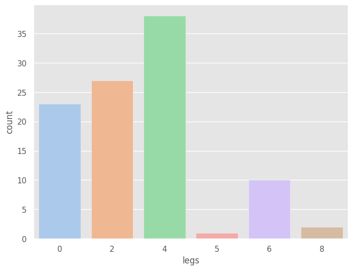

```python
pastel_palette = sns.color_palette("pastel", 6)
plt.style.use("ggplot")
fig, ax = plt.subplots(figsize=(8,6))
sns.countplot(x=zoo["legs"], order=[0, 2, 4, 5, 6, 8], palette=pastel_palette)
plt.show()
```

Widzimy jak rozkłada się liczba nóg w naszym zbiorze danych. Większość zwierząt ma 4 nogi, na drugim miejscu mamy zwierzęta z dwiema nogami. Najmniej zwierząt w naszym zbiorze danych posiada 5 nóg.

#### Liczebność w poszczególnych kolumnach

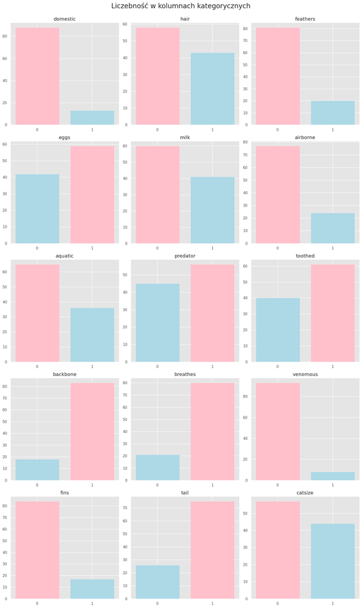

```python
plt.style.use("ggplot")
fig, ax = plt.subplots(5, 3, figsize=(15, 25))

columns = [
    "domestic", "hair", "feathers", "eggs", "milk",
    "airborne", "aquatic", "predator", "toothed",
    "backbone", "breathes", "venomous", "fins",
    "tail", "catsize"
]

colors = ['pink', 'lightblue']

for i, column in enumerate(columns):
    row = i // 3
    col = i % 3
    counts = zoo[column].value_counts()
    ax[row, col].bar(counts.index, counts.values, color=colors[:len(counts)])
    ax[row, col].set_title(column)
    ax[row, col].set_xticks([0, 1])
    ax[row, col].set_xticklabels(['0', '1'])
    ax[row, col].set_xlabel("")

plt.suptitle('Liczebność w kolumnach kategorycznych', fontsize=20, y=1)
plt.tight_layout()
plt.show()
```

Wykres ten pokazuje jak wyglądają nasze dane w zależności od kolumn. Na każdym z pojedynczych wykresów mamy osobną kolumnę i to jak rozkładają się "0" i "1", czyli ile zwierząt ma lub nie ma określonej cechy.

Możemy na przykład zauważyć, że większość zwierząt w naszym zbiorze danych nie jest udomowionych, nie posiada piór, nie potrafi latać i nie jest jadowita. Natomiast zdecydowana większość posiada kręgosłup, oddycha powietrzem oraz posiada ogon.

# Przykłady podobnych zwierząt

Ustawiamy kolumnę `animal_name` jako indeks DataFrame'u `zoo`.

```python
zoo.set_index('animal_name',inplace=True)
```

Będziemy obliczać podobieństwo cosinusowe między dwoma zwierzętami w zbiorze danych zoo, co pozwoli nam na ocenę, jak bardzo są one podobne pod względem cech, które mamy w naszej tabeli.

```python
cosine_similarity(zoo.loc[['lion']],zoo.loc[['leopard']])
```

```
array([[1.]])
```

Wynik oznacza, że dane opisujące lwa i lamparta w zbiorze zoo są identyczne. Jest to możliwe tylko wtedy, gdy wszystkie cechy użyte do opisania tych zwierząt mają dokładnie te same wartości. W kontekście uczenia maszynowego i analizy danych, taki wynik wskazuje na maksymalną możliwą podobność między dwoma wierszami danych.

```python
cosine_similarity(zoo.loc[['wolf']],zoo.loc[['sparrow']])
```

```
array([[0.69487923]])
```

Podobieństwo między wilkiem a wróblem wynosi 0.69

```python
cosine_similarity(zoo.loc[['vulture']],zoo.loc[['sparrow']])
```

```
array([[0.93541435]])
```

Bardzo wysoka wartość podobieństwa cosinusowego bliska 1 sugeruje, że sęp i wróbel mają wiele cech wspólnych w zbiorze danych.

### Metoda przewidywania zwierząt

Definiujemy funkcję `get_similar_animals`, która oblicza podobieństwo cosinusowe między danym zwierzęciem, a wszystkimi innymi zwierzętami w DataFrame `zoo`, a następnie zwraca n najbardziej podobnych zwierząt (do maksymalnie 101). Funkcja usuwa kolumnę `class_type` przed obliczeniami, a wyniki sortuje malejąco według podobieństwa.

```python
def get_similar_animals(animal,n=5):
    if n>101:
        raise ValueError("Nie można wybrać wartości n większej niż 101.")
    ndf = zoo.drop('class_type',axis=1)
    similarity = []
    animals = []
    for animal_name in ndf.index:
        if animal != animal_name:
            sim = cosine_similarity(ndf.loc[[animal]],ndf.loc[[animal_name]])[0][0]*100
            animals.append(animal_name)
            similarity.append(sim)
    similar_animals = pd.DataFrame({'Podobne zwierzęta':animals,'Podobieństwo':similarity})
    similar_animals.sort_values(by='Podobieństwo',inplace=True,ascending=False)
    return similar_animals.head(n)
```

Nastepnie definiujemy funkcję `plot_similarity_barh`, która generuje wykres słupkowy przedstawiający podobieństwo między danym zwierzęciem, a innymi zwierzętami w naszym zbiorze danych.

```python
def plot_similarity_barh(animal_df, animal_name, color='pink'):
    plt.title(f"Zwierzęta podobne do {animal_name}")
    sns.barplot(data=animal_df, y='Podobne zwierzęta', x='Podobieństwo', color=color)
    plt.show()
```

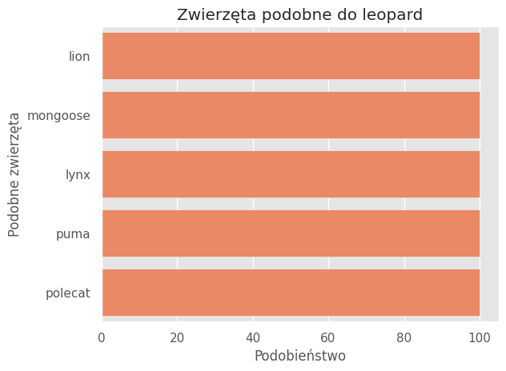

```python
case1 = get_similar_animals('leopard',5)
plot_similarity_barh(case1,'leopard', color='#FF7F50')
```

Obliczamy podobieństwo między lampartem a innymi zwierzętami, a następnie zwracamy 5 najbardziej podobnych zwierząt. Są to: lew, mangusta, ryś, puma, tchórz.

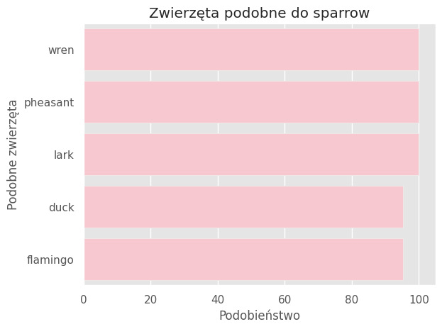

```python
case2 = get_similar_animals('sparrow',5)
plot_similarity_barh(case2,'sparrow', color='#FFC0CB')
```

Zwierzęta najbardziej podobne do wróbla to: strzyżyk, bażant, skowronek, kaczka i flaming.

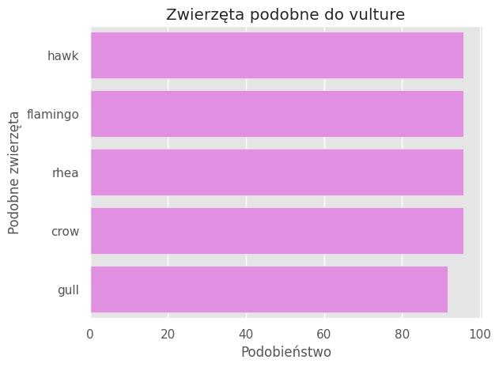

```python
case3 = get_similar_animals('vulture',5)
plot_similarity_barh(case3,'vulture', color='#EE82EE')
```

Zwierzęta najbardziej podobne do sępa: jastrząb, flaming, reja, wrona i mewa.

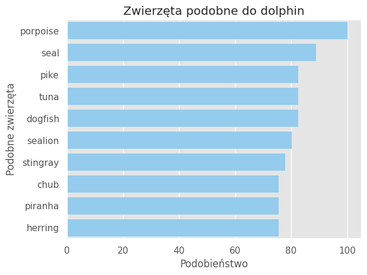

```python
case4 = get_similar_animals('dolphin',10)
plot_similarity_barh(case4,'dolphin', color='#87CEFA')
```

Zwierzęta najbardziej podobne do delfina to: morświn, foka, szczupak, tuńczyk, itd.

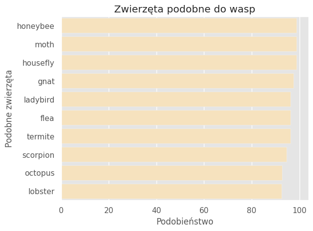

```python
case5 = get_similar_animals('wasp',10)
plot_similarity_barh(case5,'wasp', color='#FFE4B5')
```

Zwierzęta najbardziej podobne do osy: pszczoła, ćma, mucha, komar, itd.

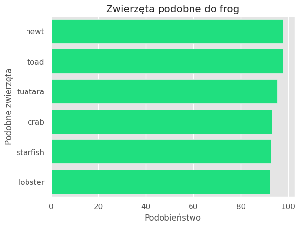

```python
case6 = get_similar_animals('frog',6)
plot_similarity_barh(case6,'frog', color='#00FF7F')
```

Zwierzęta najbardziej podobne do żaby: traszka, ropucha, tuatara, krab, itd.

## Macierz wykresów rozrzutu

Tworzymy macierz wykresów rozrzutu dla każdej pary zmiennych w zbiorze danych. Dla zmiennych numerycznych, na przekątnej macierzy, rysowane są wykresy gęstości.

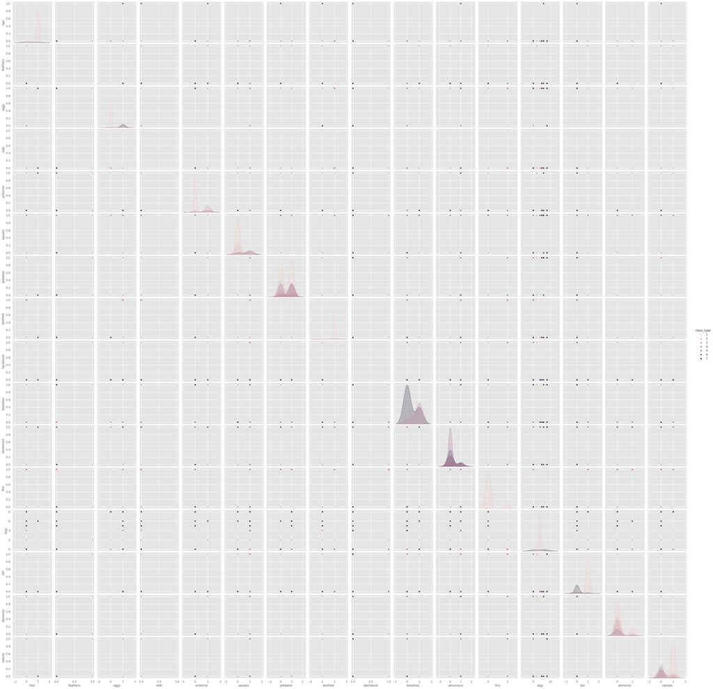

```python
sns.pairplot(zoo, hue='class_type')
```

Wynik działania kodu dostarcza wizualnej reprezentacji danych, co może być bardzo pomocne w eksploracyjnej analizie danych (EDA). Dzięki temu można zidentyfikować wzorce i zależności między różnymi cechami zwierząt, a ich klasyfikacją.

## Macierz korelacji

```python
zoo.select_dtypes(include='number').corr()
```

|  | hair | feathers | eggs | milk | airborne | aquatic | predator | toothed | backbone | breathes | venomous | fins | legs | tail | domestic | catsize | class_type |
| --- | --- | --- | --- | --- | --- | --- | --- | --- | --- | --- | --- | --- | --- | --- | --- | --- | --- |
| hair | 1.000000 | -0.427851 | -0.817382 | 0.878503 | -0.198431 | -0.473554 | -0.154769 | 0.492531 | 0.191681 | 0.441149 | -0.104245 | -0.280313 | 0.394009 | 0.048973 | 0.207208 | 0.455020 | -0.562384 |
| feathers | -0.427851 | 1.000000 | 0.419248 | -0.410761 | 0.656553 | -0.058552 | -0.104430 | -0.613631 | 0.231403 | 0.254588 | -0.145739 | -0.223541 | -0.206686 | 0.292569 | 0.031586 | -0.135934 | -0.197520 |
| eggs | -0.817382 | 0.419248 | 1.000000 | -0.938848 | 0.376646 | 0.376244 | 0.011605 | -0.642150 | -0.340420 | -0.382777 | 0.098689 | 0.164796 | -0.224918 | -0.221090 | -0.155610 | -0.514650 | 0.661825 |
| milk | 0.878503 | -0.410761 | -0.938848 | 1.000000 | -0.366765 | -0.362613 | -0.029721 | 0.628168 | 0.384958 | 0.423527 | -0.242449 | -0.156328 | 0.214196 | 0.210026 | 0.163928 | 0.574906 | -0.723683 |
| airborne | -0.198431 | 0.656553 | 0.376646 | -0.366765 | 1.000000 | -0.172638 | -0.295181 | -0.594311 | -0.104718 | 0.286039 | 0.008528 | -0.251157 | 0.043712 | 0.009482 | 0.063274 | -0.349768 | 0.022677 |
| aquatic | -0.473554 | -0.058552 | 0.376244 | -0.362613 | -0.172638 | 1.000000 | 0.375978 | 0.053150 | 0.022463 | -0.637506 | 0.087915 | 0.604492 | -0.360638 | -0.034642 | -0.224308 | -0.111866 | 0.326639 |
| predator | -0.154769 | -0.104430 | 0.011605 | -0.029721 | -0.295181 | 0.375978 | 1.000000 | 0.129452 | 0.051022 | -0.262931 | 0.115391 | 0.190302 | -0.099723 | 0.018947 | -0.309794 | 0.144790 | 0.061179 |
| toothed | 0.492531 | -0.613631 | -0.642150 | 0.628168 | -0.594311 | 0.053150 | 0.129452 | 1.000000 | 0.575085 | -0.065690 | -0.062344 | 0.364292 | -0.193476 | 0.310368 | 0.069430 | 0.344010 | -0.471527 |
| backbone | 0.191681 | 0.231403 | -0.340420 | 0.384958 | -0.104718 | 0.022463 | 0.051022 | 0.575085 | 1.000000 | 0.207666 | -0.246611 | 0.209499 | -0.432856 | 0.731762 | 0.101733 | 0.356976 | -0.828845 |
| breathes | 0.441149 | 0.254588 | -0.382777 | 0.423527 | 0.286039 | -0.637506 | -0.262931 | -0.065690 | 0.207666 | 1.000000 | -0.120752 | -0.617219 | 0.369868 | 0.088952 | 0.124068 | 0.204125 | -0.519308 |
| venomous | -0.104245 | -0.145739 | 0.098689 | -0.242449 | 0.008528 | 0.087915 | 0.115391 | -0.062344 | -0.246611 | -0.120752 | 1.000000 | -0.033956 | 0.022964 | -0.162724 | -0.003252 | -0.183748 | 0.321476 |
| fins | -0.280313 | -0.223541 | 0.164796 | -0.156328 | -0.251157 | 0.604492 | 0.190302 | 0.364292 | 0.209499 | -0.617219 | -0.033956 | 1.000000 | -0.605652 | 0.204349 | -0.093887 | 0.031705 | 0.099430 |
| legs | 0.394009 | -0.206686 | -0.224918 | 0.214196 | 0.043712 | -0.360638 | -0.099723 | -0.193476 | -0.432856 | 0.369868 | 0.022964 | -0.605652 | 1.000000 | -0.348295 | 0.073931 | 0.068791 | 0.131693 |
| tail | 0.048973 | 0.292569 | -0.221090 | 0.210026 | 0.009482 | -0.034642 | 0.018947 | 0.310368 | 0.731762 | 0.088952 | -0.162724 | 0.204349 | -0.348295 | 1.000000 | 0.023434 | 0.243277 | -0.631830 |
| domestic | 0.207208 | 0.031586 | -0.155610 | 0.163928 | 0.063274 | -0.224308 | -0.309794 | 0.069430 | 0.101733 | 0.124068 | -0.003252 | -0.093887 | 0.073931 | 0.023434 | 1.000000 | 0.020073 | -0.181043 |
| catsize | 0.455020 | -0.135934 | -0.514650 | 0.574906 | -0.349768 | -0.111866 | 0.144790 | 0.344010 | 0.356976 | 0.204125 | -0.183748 | 0.031705 | 0.068791 | 0.243277 | 0.020073 | 1.000000 | -0.521030 |
| class_type | -0.562384 | -0.197520 | 0.661825 | -0.723683 | 0.022677 | 0.326639 | 0.061179 | -0.471527 | -0.828845 | -0.519308 | 0.321476 | 0.099430 | 0.131693 | -0.631830 | -0.181043 | -0.521030 | 1.000000 |

Wynikiem działania tego kodu jest macierz korelacji, która pozwala zobaczyć, jak silnie powiązane są ze sobą różne cechy numeryczne w zbiorze danych zoo. Współczynnik korelacji Pearsona przyjmuje wartości od -1 do 1, gdzie:

- 1 oznacza idealną korelację dodatnią (gdy jedna zmienna rośnie, druga również rośnie w stałym stosunku),
- -1 oznacza idealną korelację ujemną (gdy jedna zmienna rośnie, druga maleje w stałym stosunku),
- 0 oznacza brak liniowej korelacji między zmiennymi.

Zobaczmy jak to przestawia się na rysunku

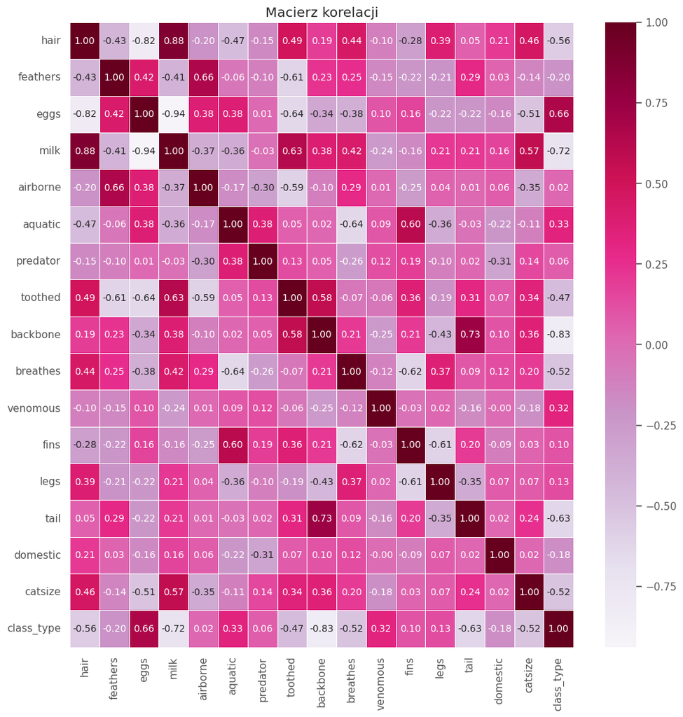

```python
dane_numeryczne = zoo.select_dtypes(include='number')
macierz_korelacji = dane_numeryczne.corr()


plt.figure(figsize=(12, 12))
heatmap = sns.heatmap(macierz_korelacji, annot=True, cmap='PuRd', fmt=".2f", linewidths=0.5)

plt.title('Macierz korelacji')

plt.show()
```

Na podstawie przedstawionej macierzy korelacji dla danych numerycznych z zestawu danych dotyczących zwierząt, można zauważyć kilka istotnych zależności:

Macierz korelacji pokazuje, że niektóre cechy zwierząt są silnie powiązane, co może być użyteczne przy klasyfikacji lub grupowaniu zwierząt na podstawie ich cech fizycznych i behawioralnych.

## Wskaźnik VIF

Sprawdźmy jeszcze wskaźnik VIF (Variance Inflation Factor) w kolumnach numerycznych. Aby go obliczyć należy dodać stałą kolumnę równą 1, a następnie sortujmy wyniki w kolejności od największej do najmniejszej.

```python
columns_v2 = [
    "domestic", "hair", "feathers", "eggs", "milk",
    "airborne", "aquatic", "predator", "toothed",
    "backbone", "breathes", "venomous", "fins",
    "tail", "catsize", "legs"
]

zoo_vif = zoo.copy()
zoo_vif['const'] = 1

X = zoo_vif[columns_v2 + ['const']]

vif_info = pd.DataFrame()
vif_info['Column'] = X.columns
vif_info['VIF'] = [variance_inflation_factor(X.values, i) for i in range(X.shape[1])]
vif_info = vif_info.sort_values('VIF', ascending=False)

vif_info
```

|  | Column | VIF |
| --- | --- | --- |
| 16 | const | 86.042608 |
| 4 | milk | 25.949405 |
| 8 | toothed | 18.805725 |
| 9 | backbone | 14.893443 |
| 3 | eggs | 14.802079 |
| 2 | feathers | 13.682119 |
| 1 | hair | 8.194089 |
| 12 | fins | 3.599490 |
| 10 | breathes | 3.401064 |
| 5 | airborne | 2.999686 |
| 15 | legs | 2.873312 |
| 13 | tail | 2.794263 |
| 6 | aquatic | 2.766974 |
| 14 | catsize | 1.970174 |
| 11 | venomous | 1.664259 |
| 7 | predator | 1.456784 |
| 0 | domestic | 1.226925 |

Zaprezentujmy otrzymane wartości na wykresie dla lepszego zrozumienia wyników. Usuńmy kolumnę `const`, która jest niepotrzebna, ponieważ była dodana tylko w celu prawidłowego obliczenia wskaźnika VIF.

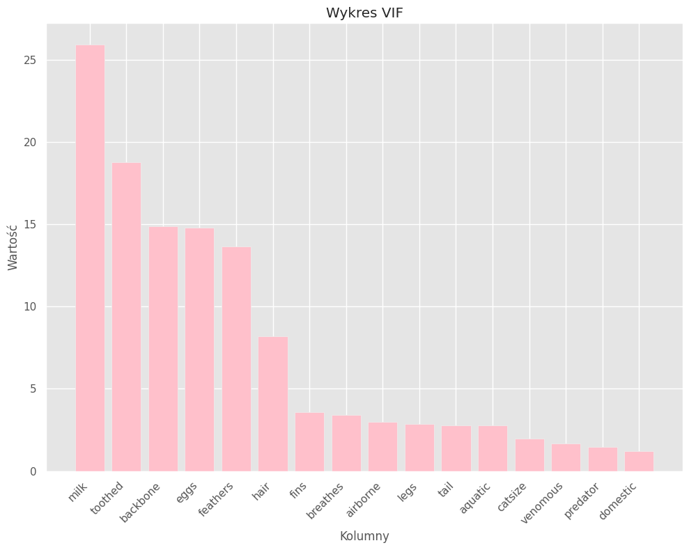

```python
vif_info_filtered = vif_info[vif_info['Column'] != 'const']
vif_info_sorted = vif_info_filtered.sort_values('VIF', ascending=False)

plt.figure(figsize=(10, 8))
plt.bar(vif_info_sorted['Column'], vif_info_sorted['VIF'], color='pink')
plt.xlabel('Kolumny')
plt.ylabel('Wartość')
plt.title('Wykres VIF')
plt.xticks(rotation=45, ha='right')
plt.tight_layout()
plt.show()
```

Obliczony wskaźnik jest w stanie pokazać nam jak konkretne dane wpływają na siebie. Na podstawie wykresu możemy zobaczyć, że wskaźnik osiąga wysokie wartości dla `milk` i `toothed`, co oznacza silną współliniowość tych zmiennych z innymi cechami, co może zaburzać modele regresji. Kolejne zmienne takie jak `backbone`, `eggs`, czy `feathers` mają umiarkowane wartości wskaźnika, co również może wskazywać na pewną współliniowość między tymi danymi. Pozostałe zmienne osiągają niewielkie wartości obliczanego wskaźnika, co oznacza zdecydowanie mniejszą współliniowość, a co za tym idzie zdecydowanie mniejsze ryzyko problemów w dalszych analizach.

## Przygotowanie danych

```python
ind_col = [col for col in zoo.columns if col not in ['class_type', 'animal_name']]

dep_col = 'class_type'

X = zoo[ind_col]
y = zoo[dep_col]
```

Dzielimy zbiór na treningowy i testowy w proporcji 3:1. 75% danych będziemy przeznaczać na zbiór treningowy, na któych będziemy uczyli nasze modele, natomiast pozostałe 25% przeznaczamy na zbiór testowy.

```python
X_train, X_test, y_train, y_test = train_test_split(X, y, test_size = 0.25, random_state = seed)
```

Przeprowadźmy normalizację naszych danych w celu przygotowania danych do efektywnego i spójnego trenowania modeli uczenia maszynowego, co prowadzi do lepszych wyników i bardziej stabilnych modeli.

Standaryzacja sprawia, że dane mają zerową średnią i jednostkowe odchylenie standardowe, co może poprawić wydajność i szybkość konwergencji algorytmów uczenia maszynowego.

```python
scaler = StandardScaler()
X_train = scaler.fit_transform(X_train)
X_test = scaler.transform(X_test)
```

## Uczenie nienadzorowane

Uczenie nienadzorowane to gałąź sztucznej inteligencji, która pozwala modelom analizować i interpretować dane bez nadzoru człowieka. W przeciwieństwie do uczenia nadzorowanego, gdzie modele uczą się na podstawie oznaczonych danych, w uczeniu nienadzorowanym algorytmy muszą samodzielnie odkrywać wzorce i struktury w nieoznaczonych zbiorach danych. Tego typu techniki znajdują zastosowanie w różnych dziedzinach, takich jak analiza klastrów, redukcja wymiarów i wykrywanie anomalii, umożliwiając bardziej zaawansowane i autonomiczne rozwiązania.

### K-Means

Algorytm K-means to popularna technika uczenia nienadzorowanego, stosowana do grupowania danych w zbiory o podobnych cechach. Polega on na podziale zbioru danych na k klastrów, w taki sposób, aby minimalizować sumę odległości punktów od ich odpowiednich centroidów. Dzięki swojej prostocie i efektywności, K-means jest szeroko używany w analizie danych, segmentacji klientów oraz kompresji obrazu.

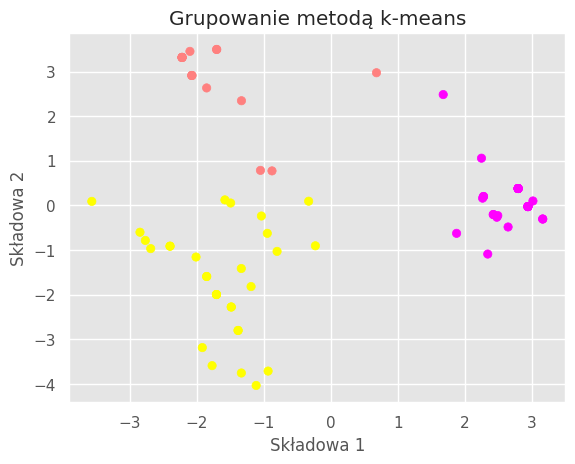

```python
kmeans = KMeans(n_clusters = 3, random_state = seed_v2)
kmeans.fit(X_train)

predicted_labels = kmeans.labels_

pca = PCA(n_components = 3, random_state = seed_v2)
X_train_pca = pca.fit_transform(X_train)

plt.scatter(X_train_pca[:, 0], X_train_pca[:, 1], c = predicted_labels, cmap = 'spring')
plt.xlabel('Składowa 1')
plt.ylabel('Składowa 2')
plt.title('Grupowanie metodą k-means')
plt.show()
```

Kod ten wykonuje grupowanie metodą K-means na zbiorze danych treningowych oraz wizualizuje wyniki przy użyciu analizy głównych składowych (PCA). Najpierw, algorytm K-means dzieli dane na trzy klastry, a wyniki tego podziału są zapisywane w zmiennej predicted_labels. Następnie, dane są redukowane do trzech wymiarów za pomocą PCA, aby umożliwić ich wizualizację na dwuwymiarowym wykresie. Ostatecznie, wykres rozproszenia przedstawia punkty danych w przestrzeni PCA, z kolorami odpowiadającymi przypisanym klastrom.

Interpretacja wyniku polega na analizie wykresu, gdzie każdy punkt reprezentuje obiekt (zwierzę) w dwóch wymiarach po redukcji za pomocą PCA, a kolory punktów wskazują przynależność do jednego z trzech klastrów utworzonych przez algorytm K-means. Widoczność wyraźnych skupisk o różnych kolorach sugeruje, że algorytm skutecznie podzielił dane na różne grupy zwierząt o podobnych cechach.

### Grupowanie aglomeracyjne

Grupowanie aglomeracyjne to hierarchiczna metoda klasteryzacji, która iteracyjnie łączy najbliższe pary punktów danych lub grup, tworząc coraz większe klastry. Proces ten zaczyna się od traktowania każdego punktu danych jako osobnego klastru i kończy, gdy wszystkie punkty zostaną połączone w jeden duży klaster. Dzięki swojej zdolności do tworzenia hierarchii, grupowanie aglomeracyjne jest szczególnie użyteczne w analizie złożonych struktur danych i wykrywaniu zależności na różnych poziomach szczegółowości.

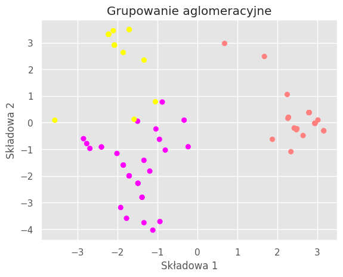

```python
kmeans = AgglomerativeClustering(n_clusters = 3)
kmeans.fit(X_train)

predicted_labels = kmeans.labels_

pca = PCA(n_components = 3, random_state = seed_v2)
X_train_pca = pca.fit_transform(X_train)

plt.scatter(X_train_pca[:, 0], X_train_pca[:, 1], c = predicted_labels, cmap = 'spring')
plt.xlabel('Składowa 1')
plt.ylabel('Składowa 2')
plt.title('Grupowanie aglomeracyjne')
plt.show()
```

Każdy punkt reprezentuje obiekt (zwierzę) w dwóch wymiarach po redukcji za pomocą PCA, a kolory punktów wskazują przynależność do jednego z trzech klastrów utworzonych przez algorytm grupowania aglomeracyjnego. Wyraźne skupiska o różnych kolorach sugerują, że algorytm skutecznie podzielił dane na różne grupy zwierząt o podobnych cechach, ukazując hierarchiczne relacje między nimi.

###### Porównanie

Porównując obie metody algorytm K-means dzieli dane na k klastrów, minimalizując sumę odległości punktów od ich odpowiednich centroidów, co czyni go szybszym i bardziej efektywnym w przypadku dużych zbiorów danych o wyraźnych podziałach. Z kolei grupowanie aglomeracyjne buduje hierarchię klastrów poprzez iteracyjne łączenie najbliższych punktów lub grup, co umożliwia bardziej szczegółową analizę struktur danych, ale jest zazwyczaj wolniejsze i bardziej obciążające obliczeniowo.

## Uczenie nadzorowane

Uczenie nadzorowane to metoda sztucznej inteligencji, w której modele uczą się na podstawie oznaczonych danych wejściowych i odpowiadających im wyjściowych wartości. Proces ten polega na dopasowywaniu modelu do zbioru treningowego, tak aby mógł przewidywać wyniki dla nowych, nieznanych danych. Uczenie nadzorowane jest szeroko stosowane w zadaniach takich jak klasyfikacja, regresja oraz rozpoznawanie obrazów, dzięki swojej zdolności do dokładnego modelowania zależności między zmiennymi.

## Regresja liniowa

Regresja liniowa to technika uczenia nadzorowanego, która modeluje zależność między zmienną niezależną a zmienną zależną poprzez dopasowanie prostej linii do danych. Metoda ta jest szeroko stosowana do przewidywania wartości ciągłych oraz analizy związków między zmiennymi, co czyni ją fundamentalnym narzędziem w statystyce i uczeniu maszynowym.

```python
linreg = LinearRegression()

linreg.fit(X_train, y_train)

y_pred = linreg.predict(X_test)

mse = mean_squared_error(y_test, y_pred)
r2 = r2_score(y_test, y_pred)

print(f"Mean Squared Error: {mse}")
print(f"R^2 Score: {r2}")
```

```
Mean Squared Error: 0.556888477846862
R^2 Score: 0.8993431521324923
```

Kod ten trenuje model regresji liniowej na zbiorach treningowych, a następnie używa go do przewidywania wartości dla zbioru testowego. Następnie oblicza średni błąd kwadratowy (MSE) oraz współczynnik determinacji (R²) dla prognozowanego zestawu danych testowych, wyświetlając te metryki.

Interpretacja wyniku:

- Średni błąd kwadratowy (MSE) wynoszący 0.556888477846862 wskazuje na stosunkowo niewielką różnicę między wartościami rzeczywistymi a przewidywanymi przez model.
- Współczynnik determinacji (R²) wynoszący 0.8993431521324923 sugeruje, że model wyjaśnia około 89.93% zmienności w danych testowych, co oznacza bardzo dobrą jakość dopasowania modelu do danych.

## Regresja logistyczna

Regresja logistyczna to popularna metoda uczenia maszynowego wykorzystywana do modelowania relacji między zmiennymi niezależnymi a binarnymi zmiennymi zależnymi. Jest powszechnie stosowana do prognozowania prawdopodobieństwa przynależności do jednej z dwóch klas, co czyni ją idealnym narzędziem do zadań klasyfikacji binarnej.

```python
logreg = LogisticRegression(random_state = seed)
logreg.fit(X_train, y_train)
y_pred = logreg.predict(X_test)

print(f'Dokładność na zbiorze treningowym wynosi: {accuracy_score(y_train, logreg.predict(X_train))}\n')

logreg_accuracy = accuracy_score(y_test, y_pred)
logreg_precision = precision_score(y_test, y_pred, average='macro')
logreg_recall = recall_score(y_test, y_pred, average='macro')
logreg_f1_score = f1_score(y_test, y_pred, average='macro')

print(f"Macierz pomyłek: \n{confusion_matrix(y_test, y_pred)}\n")
print(f"Dokładność na zbiorze testowym: {logreg_accuracy} \n")
print(f"Precyzja na zbiorze testowym: {logreg_precision} \n")
print(f"Wskaźnik Recall na zbiorze testowym: {logreg_recall} \n")
print(f"F1_score na zbiorze testowym: {logreg_f1_score} \n")
print(f"Raport klasyfikacji: \n{classification_report(y_test, y_pred)}")
```

```
Dokładność na zbiorze treningowym wynosi: 1.0

Macierz pomyłek:
[[11  0  0  0  0  0  0]
 [ 0  6  0  0  0  0  0]
 [ 0  0  1  0  0  0  0]
 [ 0  0  0  1  0  0  0]
 [ 0  0  0  0  1  0  0]
 [ 0  0  0  0  0  1  0]
 [ 0  0  1  0  0  2  2]]

Dokładność na zbiorze testowym: 0.8846153846153846

Precyzja na zbiorze testowym: 0.8333333333333333

Wskaźnik Recall na zbiorze testowym: 0.9142857142857144

F1_score na zbiorze testowym: 0.8197278911564625

Raport klasyfikacji:
              precision    recall  f1-score   support

           1       1.00      1.00      1.00        11
           2       1.00      1.00      1.00         6
           3       0.50      1.00      0.67         1
           4       1.00      1.00      1.00         1
           5       1.00      1.00      1.00         1
           6       0.33      1.00      0.50         1
           7       1.00      0.40      0.57         5

    accuracy                           0.88        26
   macro avg       0.83      0.91      0.82        26
weighted avg       0.96      0.88      0.89        26
```

Otrzymane wyniki prezentują ocenę wydajności modelu klasyfikacji na zbiorze testowym. "Dokładność na zbiorze treningowym wynosi: 1.0" oznacza, że model poprawnie sklasyfikował wszystkie dane treningowe, co sugeruje, że model idealnie dopasował się do tych danych, ale może być również sygnałem nadmiernego dopasowania (overfittingu). Macierz pomyłek przedstawia liczbę poprawnie sklasyfikowanych przypadków dla każdej klasy oraz przypadki błędnie sklasyfikowane, pozwalając na wgląd w błędy modelu. Pozostałe metryki, takie jak precyzja, recall, F1-score i raport klasyfikacji, są wyznacznikami wydajności modelu na zbiorze testowym, gdzie wartości bliskie 1.0 sugerują dobrą wydajność, a wartości bliskie 0.0 mogą wskazywać na słabsze dopasowanie modelu do danych testowych. Dla dokładności na zbiorze testowym, precyzji, recall, i F1-score o wartościach bliskich 1.0 oraz wysokim wskaźniku macro avg, wyniki te sugerują, że model radzi sobie dobrze z klasyfikacją danych testowych.

### K-najbliższych sąsiadów

Algorytm k-najbliższych sąsiadów (k-NN) to prosty, ale skuteczny algorytm uczenia maszynowego, który przewiduje klasy lub wartości dla nowych danych na podstawie podobieństwa do najbliższych sąsiadów w zbiorze treningowym. W tej metodzie klasyfikacji lub regresji, k-NN wybiera k najbardziej podobnych obserwacji znanego zbioru danych, wykorzystując miarę odległości, taką jak odległość euklidesowa, aby dokonać prognozy dla nowych danych.

```python
knn = KNeighborsClassifier()

knn.fit(X_train, y_train)

y_pred = knn.predict(X_test)

print(f'Dokładność na zbiorze treningowym wynosi: {accuracy_score(y_train, knn.predict(X_train))}\n')

knn_accuracy = accuracy_score(y_test, y_pred)
knn_precision = precision_score(y_test, y_pred, average='macro')
knn_recall = recall_score(y_test, y_pred, average='macro')
knn_f1_score = f1_score(y_test, y_pred, average='macro')

print(f"Macierz pomyłek: \n{confusion_matrix(y_test, y_pred)}\n")
print(f"Dokładność na zbiorze testowym: {knn_accuracy} \n")
print(f"Precyzja na zbiorze testowym: {knn_precision} \n")
print(f"Wskaźnik Recall na zbiorze testowym: {knn_recall} \n")
print(f"F1_score na zbiorze testowym: {knn_f1_score} \n")
print(f"Raport klasyfikacji: \n {classification_report(y_test, y_pred)}")
```

```
Dokładność na zbiorze treningowym wynosi: 0.9733333333333334

Macierz pomyłek:
[[11  0  0  0  0  0  0]
 [ 0  6  0  0  0  0  0]
 [ 0  0  1  0  0  0  0]
 [ 0  0  0  1  0  0  0]
 [ 0  0  0  0  1  0  0]
 [ 0  0  0  0  0  1  0]
 [ 0  0  0  0  0  3  2]]

Dokładność na zbiorze testowym: 0.8846153846153846

Precyzja na zbiorze testowym: 0.8928571428571429

Wskaźnik Recall na zbiorze testowym: 0.9142857142857144

F1_score na zbiorze testowym: 0.8530612244897959

Raport klasyfikacji:
               precision    recall  f1-score   support

           1       1.00      1.00      1.00        11
           2       1.00      1.00      1.00         6
           3       1.00      1.00      1.00         1
           4       1.00      1.00      1.00         1
           5       1.00      1.00      1.00         1
           6       0.25      1.00      0.40         1
           7       1.00      0.40      0.57         5

    accuracy                           0.88        26
   macro avg       0.89      0.91      0.85        26
weighted avg       0.97      0.88      0.89        26
```

Wyniki analizy wydajności modelu k-najbliższych sąsiadów (k-NN) wskazują na wysoką dokładność na zbiorze treningowym, wynoszącą 97.33%, co sugeruje dobrze dopasowany model do danych treningowych. Macierz pomyłek prezentuje ilość poprawnie i błędnie sklasyfikowanych przypadków dla każdej klasy w zbiorze testowym, gdzie wartości na przekątnej odpowiadają poprawnym klasyfikacjom. Analiza metryk na zbiorze testowym, takich jak dokładność (88.46%), precyzja (89.29%), recall (91.43%) i F1-score (85.31%), wskazuje na dobrą zdolność modelu do klasyfikacji, choć warto zauważyć, że dla niektórych klas współczynnik precyzji lub recall może być niższy, co sugeruje pewne trudności w rozróżnieniu tych klas przez model.

### Drzewo decyzyjne

Drzewa decyzyjne są często stosowanym algorytmem w uczeniu maszynowym, używanym zarówno w zadaniach klasyfikacji, jak i regresji. Te modele operują na podstawie struktury hierarchicznej, gdzie decyzje są podejmowane na podstawie sekwencji warunków, tworząc przejrzystą ścieżkę decyzyjną. Ich elastyczność, zdolność do obsługi zarówno danych liczbowych, jak i kategorycznych, oraz możliwość łatwej interpretacji czynią je popularnym narzędziem w analizie danych i podejmowaniu decyzji.

```python
dtree = DecisionTreeClassifier(random_state = seed)
dtree.fit(X_train, y_train)
y_pred = dtree.predict(X_test)

print(f'Dokładność na zbiorze treningowym wynosi: {accuracy_score(y_train, dtree.predict(X_train))}\n')

dtree_accuracy = accuracy_score(y_test, y_pred)
dtree_precision = precision_score(y_test, y_pred, average='macro')
dtree_recall = recall_score(y_test, y_pred, average='macro')
dtree_f1_score = f1_score(y_test, y_pred, average='macro')

print(f"Macierz pomyłek: \n{confusion_matrix(y_test, y_pred)}\n")
print(f"Dokładność na zbiorze testowym: {dtree_accuracy} \n")
print(f"Precyzja na zbiorze testowym: {dtree_precision} \n")
print(f"Wskaźnik Recall na zbiorze testowym: {dtree_recall} \n")
print(f"F1_score na zbiorze testowym: {dtree_f1_score} \n")
print(f"Raport klasyfikacji: \n{classification_report(y_test, y_pred)}")
```

```
Dokładność na zbiorze treningowym wynosi: 1.0

Macierz pomyłek:
[[11  0  0  0  0  0  0]
 [ 0  6  0  0  0  0  0]
 [ 0  0  1  0  0  0  0]
 [ 0  0  0  1  0  0  0]
 [ 0  0  0  0  1  0  0]
 [ 0  0  0  0  0  1  0]
 [ 0  0  0  0  0  4  1]]

Dokładność na zbiorze testowym: 0.8461538461538461

Precyzja na zbiorze testowym: 0.8857142857142858

Wskaźnik Recall na zbiorze testowym: 0.8857142857142858

F1_score na zbiorze testowym: 0.8095238095238094

Raport klasyfikacji:
              precision    recall  f1-score   support

           1       1.00      1.00      1.00        11
           2       1.00      1.00      1.00         6
           3       1.00      1.00      1.00         1
           4       1.00      1.00      1.00         1
           5       1.00      1.00      1.00         1
           6       0.20      1.00      0.33         1
           7       1.00      0.20      0.33         5

    accuracy                           0.85        26
   macro avg       0.89      0.89      0.81        26
weighted avg       0.97      0.85      0.85        26
```

Otrzymane wyniki modelu drzewa decyzyjnego sugerują, że model idealnie dopasował się do danych treningowych, jednakże może być to spowodowane nadmiernym dopasowaniem. Macierz pomyłek pokazuje, jak wiele przypadków zostało poprawnie lub błędnie sklasyfikowanych dla każdej klasy w zbiorze testowym. Analiza innych metryk, takich jak dokładność, precyzja, recall i F1-score, wskazuje na ogólnie dobrą zdolność modelu do klasyfikacji, choć może on mieć trudności w rozróżnieniu pewnych klas.

### Las losowy

Las losowy to potężny algorytm uczenia maszynowego, który wykorzystuje zasadę głosowania większościowego wielu drzew decyzyjnych, aby dokonać predykcji. Działa on poprzez tworzenie wielu drzew decyzyjnych w losowy sposób i łączenie ich przewidywań w celu uzyskania bardziej stabilnych i dokładnych prognoz. Algorytm lasu losowego znajduje szerokie zastosowanie w różnych dziedzinach, od klasyfikacji do regresji, ze względu na swoją wysoką odporność na nadmierne dopasowanie i zdolność do obsługi danych o wysokiej wymiarowości.

```python
rfc = RandomForestClassifier(random_state = seed)
rfc.fit(X_train, y_train)
y_pred = rfc.predict(X_test)

print(f'Dokładność na zbiorze treningowym wynosi: {accuracy_score(y_train, rfc.predict(X_train))}\n')

rfc_accuracy = accuracy_score(y_test, y_pred)
rfc_precision = precision_score(y_test, y_pred, average='macro')
rfc_recall = recall_score(y_test, y_pred, average='macro')
rfc_f1_score = f1_score(y_test, y_pred, average='macro')

print(f"Macierz pomyłek: \n{confusion_matrix(y_test, y_pred)}\n")
print(f"Dokładność na zbiorze testowym: {rfc_accuracy} \n")
print(f"Precyzja na zbiorze testowym: {rfc_precision} \n")
print(f"Wskaźnik Recall na zbiorze testowym: {rfc_recall} \n")
print(f"F1_score na zbiorze testowym: {rfc_f1_score} \n")
print(f"Raport klasyfikacji: \n{classification_report(y_test, y_pred)}")
```

```
Dokładność na zbiorze treningowym wynosi: 1.0

Macierz pomyłek:
[[11  0  0  0  0  0  0]
 [ 0  6  0  0  0  0  0]
 [ 0  0  1  0  0  0  0]
 [ 0  0  0  1  0  0  0]
 [ 0  0  0  0  1  0  0]
 [ 0  0  0  0  0  1  0]
 [ 0  0  0  0  0  3  2]]

Dokładność na zbiorze testowym: 0.8846153846153846

Precyzja na zbiorze testowym: 0.8928571428571429

Wskaźnik Recall na zbiorze testowym: 0.9142857142857144

F1_score na zbiorze testowym: 0.8530612244897959

Raport klasyfikacji:
              precision    recall  f1-score   support

           1       1.00      1.00      1.00        11
           2       1.00      1.00      1.00         6
           3       1.00      1.00      1.00         1
           4       1.00      1.00      1.00         1
           5       1.00      1.00      1.00         1
           6       0.25      1.00      0.40         1
           7       1.00      0.40      0.57         5

    accuracy                           0.88        26
   macro avg       0.89      0.91      0.85        26
weighted avg       0.97      0.88      0.89        26
```

Wyniki oceny modelu klasyfikatora lasu losowego (Random Forest) wykazują wysoką dokładność na zbiorze treningowym, wynoszącą 100%, co sugeruje dobrze dopasowany model do danych treningowych. Macierz pomyłek przedstawia liczbę poprawnie i błędnie sklasyfikowanych przypadków dla każdej klasy w zbiorze testowym. Analiza metryk na zbiorze testowym, takich jak dokładność (88.46%), precyzja (89.29%), recall (91.43%) i F1-score (85.31%), wskazuje na dobrą zdolność modelu do klasyfikacji. Jednakże warto zauważyć, że dla niektórych klas współczynnik recall może być niższy, co sugeruje trudności w poprawnym wykryciu tych klas przez model.

### SVM

Maszyna wektorów wspierających (SVM) to potężny algorytm uczenia maszynowego, który służy zarówno do klasyfikacji, jak i regresji. Jest szczególnie efektywny w zadaniach, gdzie dane są liniowo separowalne lub mogą być transformowane w przestrzeń o większej wymiarowości, aby osiągnąć separowalność. Jego zdolność do wyznaczania optymalnej hiperpłaszczyzny separacji między klasami danych sprawia, że SVM jest popularnym narzędziem w wielu dziedzinach, od biologii i medycyny po finanse i informatykę.

```python
svm = SVC(random_state = seed)
svm.fit(X_train, y_train)
y_pred = svm.predict(X_test)

print(f'Dokładność na zbiorze treningowym wynosi: {accuracy_score(y_train, svm.predict(X_train))}\n')

svm_accuracy = accuracy_score(y_test, y_pred)
svm_precision = precision_score(y_test, y_pred, average='macro')
svm_recall = recall_score(y_test, y_pred, average='macro')
svm_f1_score = f1_score(y_test, y_pred, average='macro')

print(f"Macierz pomyłek: \n{confusion_matrix(y_test, y_pred)}\n")
print(f"Dokładność na zbiorze testowym: {svm_accuracy} \n")
print(f"Precyzja na zbiorze testowym: {svm_precision} \n")
print(f"Wskaźnik Recall na zbiorze testowym: {svm_recall} \n")
print(f"F1_score na zbiorze testowym: {svm_f1_score} \n")
print(f"Raport klasyfikacji: \n{classification_report(y_test, y_pred)}")
```

```
Dokładność na zbiorze treningowym wynosi: 1.0

Macierz pomyłek:
[[11  0  0  0  0  0  0]
 [ 0  6  0  0  0  0  0]
 [ 0  0  1  0  0  0  0]
 [ 0  0  0  1  0  0  0]
 [ 0  0  0  0  1  0  0]
 [ 0  0  0  0  0  1  0]
 [ 0  0  0  0  0  3  2]]

Dokładność na zbiorze testowym: 0.8846153846153846

Precyzja na zbiorze testowym: 0.8928571428571429

Wskaźnik Recall na zbiorze testowym: 0.9142857142857144

F1_score na zbiorze testowym: 0.8530612244897959

Raport klasyfikacji:
              precision    recall  f1-score   support

           1       1.00      1.00      1.00        11
           2       1.00      1.00      1.00         6
           3       1.00      1.00      1.00         1
           4       1.00      1.00      1.00         1
           5       1.00      1.00      1.00         1
           6       0.25      1.00      0.40         1
           7       1.00      0.40      0.57         5

    accuracy                           0.88        26
   macro avg       0.89      0.91      0.85        26
weighted avg       0.97      0.88      0.89        26
```

Wyniki klasyfikatora SVM pokazują, że model bardzo dobrze radzi sobie na danych treningowych, uzyskując idealną dokładność. Macierz pomyłek prezentuje liczbę poprawnie i błędnie sklasyfikowanych przypadków dla każdej klasy w zbiorze testowym. Analiza innych metryk, takich jak precyzja, recall i F1-score, wskazuje na ogólnie dobrą zdolność modelu do klasyfikacji, choć dla niektórych klas może wystąpić niżej współczynnik recall, co sugeruje pewne trudności w poprawnym wykryciu tych klas przez model.

### GBM

Gradient Boosting Machine (GBM) to zaawansowana technika uczenia maszynowego, która buduje silny model poprzez sekwencyjne dodawanie kolejnych słabych modeli, każdy z nich korygując błędy poprzedniego. Ten iteracyjny proces optymalizuje funkcję kosztu, pozwalając na skuteczne modelowanie złożonych zależności w danych. GBM jest powszechnie stosowany w klasyfikacji i regresji, oferując wysoką wydajność i elastyczność w różnych dziedzinach, od przetwarzania języka naturalnego po analizę obrazu.

```python
gbm = GradientBoostingClassifier(random_state = seed)
gbm.fit(X_train, y_train)
y_pred = gbm.predict(X_test)

print(f'Dokładność na zbiorze treningowym wynosi: {accuracy_score(y_train, gbm.predict(X_train))}\n')

gbm_accuracy = accuracy_score(y_test, y_pred)
gbm_precision = precision_score(y_test, y_pred, average='macro')
gbm_recall = recall_score(y_test, y_pred, average='macro')
gbm_f1_score = f1_score(y_test, y_pred, average='macro')

print(f"Macierz pomyłek: \n{confusion_matrix(y_test, y_pred)}\n")
print(f"Dokładność na zbiorze testowym: {gbm_accuracy} \n")
print(f"Precyzja na zbiorze testowym: {gbm_precision} \n")
print(f"Wskaźnik Recall na zbiorze testowym: {gbm_recall} \n")
print(f"F1_score na zbiorze testowym: {gbm_f1_score} \n")
print(f"Raport klasyfikacji: \n{classification_report(y_test, y_pred)}")
```

```
Dokładność na zbiorze treningowym wynosi: 1.0

Macierz pomyłek:
[[11  0  0  0  0  0  0]
 [ 0  6  0  0  0  0  0]
 [ 0  0  1  0  0  0  0]
 [ 0  0  0  1  0  0  0]
 [ 0  0  0  0  1  0  0]
 [ 0  0  0  0  0  1  0]
 [ 0  0  2  0  0  1  2]]

Dokładność na zbiorze testowym: 0.8846153846153846

Precyzja na zbiorze testowym: 0.8333333333333334

Wskaźnik Recall na zbiorze testowym: 0.9142857142857144

F1_score na zbiorze testowym: 0.8197278911564626

Raport klasyfikacji:
              precision    recall  f1-score   support

           1       1.00      1.00      1.00        11
           2       1.00      1.00      1.00         6
           3       0.33      1.00      0.50         1
           4       1.00      1.00      1.00         1
           5       1.00      1.00      1.00         1
           6       0.50      1.00      0.67         1
           7       1.00      0.40      0.57         5

    accuracy                           0.88        26
   macro avg       0.83      0.91      0.82        26
weighted avg       0.96      0.88      0.89        26
```

### SGBM

Ostatni z naszych modeli nosi nazwę SGBM (Stochastic Gradient Boosting Machine).

SGBM to zaawansowany algorytm uczenia maszynowego używany zarówno do klasyfikacji, jak i regresji, będący wariantem klasycznego gradient boosting machine (GBM). Różni się od GBM tym, że podczas trenowania każdego drzewa losowo wybiera podzbiory danych treningowych oraz podzbiory cech. Ten losowy komponent pomaga w zmniejszeniu przeuczenia (overfitting) i poprawia ogólną wydajność modelu.

```python
sgbm = GradientBoostingClassifier(subsample=0.7, random_state = seed)
sgbm.fit(X_train, y_train)
y_pred = sgbm.predict(X_test)

print(f'Dokładność na zbiorze treningowym wynosi: {accuracy_score(y_train, sgbm.predict(X_train))}\n')

sgbm_accuracy = accuracy_score(y_test, y_pred)
sgbm_precision = precision_score(y_test, y_pred, average='macro')
sgbm_recall = recall_score(y_test, y_pred, average='macro')
sgbm_f1_score = f1_score(y_test, y_pred, average='macro')

print(f"Macierz pomyłek: \n{confusion_matrix(y_test, y_pred)}\n")
print(f"Dokładność na zbiorze testowym: {sgbm_accuracy} \n")
print(f"Precyzja na zbiorze testowym: {sgbm_precision} \n")
print(f"Wskaźnik Recall na zbiorze testowym: {sgbm_recall} \n")
print(f"F1_score na zbiorze testowym: {sgbm_f1_score} \n")
print(f"Raport klasyfikacji: \n{classification_report(y_test, y_pred)}")
```

```
Dokładność na zbiorze treningowym wynosi: 1.0

Macierz pomyłek:
[[11  0  0  0  0  0  0]
 [ 0  6  0  0  0  0  0]
 [ 0  0  1  0  0  0  0]
 [ 0  0  0  1  0  0  0]
 [ 0  0  0  0  1  0  0]
 [ 0  0  0  0  0  1  0]
 [ 0  0  2  0  0  1  2]]

Dokładność na zbiorze testowym: 0.8846153846153846

Precyzja na zbiorze testowym: 0.8333333333333334

Wskaźnik Recall na zbiorze testowym: 0.9142857142857144

F1_score na zbiorze testowym: 0.8197278911564626

Raport klasyfikacji:
              precision    recall  f1-score   support

           1       1.00      1.00      1.00        11
           2       1.00      1.00      1.00         6
           3       0.33      1.00      0.50         1
           4       1.00      1.00      1.00         1
           5       1.00      1.00      1.00         1
           6       0.50      1.00      0.67         1
           7       1.00      0.40      0.57         5

    accuracy                           0.88        26
   macro avg       0.83      0.91      0.82        26
weighted avg       0.96      0.88      0.89        26
```

Otrzymane wyniki z użyciem Gradient Boosting Classifier (GBM) pokazują, że model bardzo dobrze dopasował się do danych treningowych, osiągając dokładność 100%. Macierz pomyłek prezentuje liczbę poprawnie i błędnie sklasyfikowanych przypadków dla każdej klasy w zbiorze testowym. Analiza innych metryk, takich jak precyzja, recall i F1-score, sugeruje, że model dobrze radzi sobie z klasyfikacją, chociaż może mieć trudności w poprawnym rozróżnieniu niektórych klas, jak sugeruje niższy recall dla niektórych z nich.

## Porównanie modeli uczenia nadzorowanego

Porównajmy nasze modele na podstawie ich dokładności i przedstawmy otrzymane wyniki na wykresie.

```python
accuracy = pd.DataFrame({
    'Model': ['Regresja logistyczna', 'KNN', 'SVM',
              'Drzewo decyzyjne', 'Las losowy',
              'GBM', 'SGBM'],
    'Wynik': np.round([logreg_accuracy, knn_accuracy, svm_accuracy,
              dtree_accuracy, rfc_accuracy, gbm_accuracy,
              sgbm_accuracy], 3)
})

accuracy_sorted = accuracy.sort_values(by='Wynik', ascending=False)
accuracy_sorted
```

|  | Model | Wynik |
| --- | --- | --- |
| 0 | Regresja logistyczna | 0.885 |
| 1 | KNN | 0.885 |
| 2 | SVM | 0.885 |
| 4 | Las losowy | 0.885 |
| 5 | GBM | 0.885 |
| 6 | SGBM | 0.885 |
| 3 | Drzewo decyzyjne | 0.846 |

Podsumowanie kodu przedstawia wyniki dokładności różnych modeli klasyfikacyjnych, w tym regresji logistycznej, KNN, SVM, drzewa decyzyjnego, lasu losowego, GBM i SGBM. Wszystkie modele osiągnęły podobne wyniki dokładności w zakresie od 84.6% do 88.5%, z regresją logistyczną, KNN, SVM, lasem losowym, GBM i SGBM uzyskując najwyższe wyniki, a drzewo decyzyjne osiągając nieco niższy wynik.

###### Porównanie jakości klasyfikatora

F1-score jest średnią harmoniczną precyzji (precision) i recall. Jest to miara jakości klasyfikatora, która uwzględnia zarówno liczbę prawdziwie pozytywnych predykcji (precision) jak i zdolność modelu do wykrycia wszystkich pozytywnych przypadków (recall). F1-score daje zrównoważoną ocenę wydajności klasyfikatora, szczególnie przy niesymetrycznych zbiorach danych, gdzie klasy mogą mieć różną liczebność. Im wyższy F1-score, tym lepiej klasyfikator radzi sobie z równowagą między precyzją a recall.

```python
f1_score = pd.DataFrame({
    'Model': ['Regresja logistyczna', 'KNN','SVM',
              'Drzewo decyzyjne', 'Las losowy',
              'GBM', 'SGBM'],
    'Wynik': np.round([logreg_f1_score, knn_f1_score, svm_f1_score,
              dtree_f1_score, rfc_f1_score, gbm_f1_score,
              sgbm_f1_score], 3)
})

f1_score_sorted = f1_score.sort_values(by='Wynik', ascending=False)
f1_score_sorted
```

|  | Model | Wynik |
| --- | --- | --- |
| 1 | KNN | 0.853 |
| 2 | SVM | 0.853 |
| 4 | Las losowy | 0.853 |
| 0 | Regresja logistyczna | 0.820 |
| 5 | GBM | 0.820 |
| 6 | SGBM | 0.820 |
| 3 | Drzewo decyzyjne | 0.810 |

```python
fig = px.bar(data_frame = f1_score_sorted, x='Wynik', y='Model', color='Wynik',
             title='Porównanie F1_score', text='Wynik')
fig.update_layout(width=1000, height=800)
fig.show()
```

[interactive chart not shown]

Ten kod tworzy ramkę danych zawierającą wyniki F1-score dla różnych modeli klasyfikacyjnych, a następnie sortuje je malejąco według wyników F1-score. Otrzymane wyniki F1-score przedstawiają ocenę jakości klasyfikatorów, gdzie najwyższe wartości wskazują na najlepszą równowagę między precyzją a recall dla poszczególnych modeli.

Interpretacja otrzymanych wyników F1-score przedstawia, że modele KNN, SVM i las losowy uzyskały najwyższe F1-score, osiągając wartość 0.853. Oznacza to, że te modele mają równowagę między precyzją a recall, co sugeruje ich skuteczność w klasyfikacji danych. Modele regresji logistycznej, GBM i SGBM uzyskały nieco niższe wyniki, osiągając 0.820, co wskazuje na nieco słabszą ocenę w porównaniu do modeli KNN, SVM i lasu losowego. Drzewo decyzyjne uzyskało najniższy wynik F1-score, 0.810, co sugeruje, że model ten może mieć trudności w osiągnięciu równowagi między precyzją a recall.

### Wnioski końcowe

W naszym projekcie operowałyśmy na danych dotyczących zwierząt w zoo. Naszym głównym celem było sklasyfikowanie zwierząt na podstawie ich różnych cech.

Zaczęłyśmy od sprawdzenia danych, podstawowych informacji o nich oraz wizualizacji na różnych wykresach. Następnie przy pomocy prawdopodobieństwa cosinusowego sprawdziłyśmy jak bardzo podobne są do siebie niektóre zwierzęta. Kolejnym krokiem, który zrobiłyśmy było znalezienie kilku najbardziej podobnych zwierząt do jednego konkretnego. Później przeszłyśmy do macierzy wykresów rozrzutu oraz macierzy korelacji, aby zobaczyć jak silnie powiązane są ze sobą różne cechy numeryczne. Ostatnim krokiem na tym etapie było sprawdzenie wskaźnika VIF i sprawdzenie jak konkretne dane wpływają na siebie.

Następnym etapem było przygotowanie danych do uczenia nienadzorowanego i nadzorowanego. Na początku podzieliłyśmy dane na zbiór treningowy i testowy. Później przeszłyśmy już bezpośrednio do uczenia nienadzorowanego, gdzie wykonałyśmy grupowanie metodą k-means oraz grupowanie aglomeracyjne. Kolejno przeszłyśmy do uczenia nadzorowanego, gdzie wykonałyśmy następujące modele: regresja liniowa, regresja logistyczna, algorytm k-najbliższych sąsiadów, drzewo decyzyjne, las losowy, SVM, GBM oraz SGBM, a następnie porównałyśmy je wszystkie.

Podsumowując, nasz projekt pozwolił na skuteczne sklasyfikowanie zwierząt w zoo na podstawie ich cech poprzez wykorzystanie zarówno metod uczenia nadzorowanego, jak i nienadzorowanego. Osiągnęłyśmy to dzięki wszechstronnej analizie danych, obliczeniom podobieństwa między zwierzętami oraz zastosowaniu zaawansowanych algorytmów klasyfikacyjnych, co umożliwiło nam dokładne porównanie i ocenę różnych modeli.